# Classification Models With stacks

In this vignette, we’ll tackle a multiclass classification problem using the stacks package. This vignette assumes that you’re familiar with tidymodels “proper,” as well as the basic grammar of the package, and have seen it implemented on numeric data; if this is not the case, check out the “Getting Started With stacks” vignette!

```r
library(tidymodels)
library(stacks)
```

In this example, we’ll make use of the `tree_frogs` data exported with `stacks`, giving experimental results on hatching behavior of red-eyed tree frog embryos!

Red-eyed tree frog (RETF) embryos can hatch earlier than their normal 7ish days if they detect potential predator threat. Researchers wanted to determine how, and when, these tree frog embryos were able to detect stimulus from their environment. To do so, they subjected the embryos at varying developmental stages to “predator stimulus” by jiggling the embryos with a blunt probe. Beforehand, though, some of the embryos were treated with gentamicin, a compound that knocks out their lateral line (a sensory organ). Researcher Julie Jung and her crew found that these factors inform whether an embryo hatches prematurely or not!

In this article, we’ll use most all of the variables in `tree_frogs` to predict `reflex`, a measure of ear function called the vestibulo-ocular reflex (VOR), categorized into bins. Ear function increases from factor levels “low”, to “mid”, to “full”.

```r
data("tree_frogs")

# subset the data
tree_frogs <- tree_frogs %>%
  select(-c(clutch, latency))
```

Let’s plot the data to get a sense for how separable these groups are.

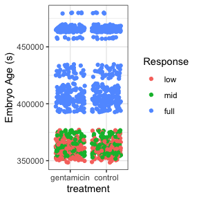

```r
theme_set(theme_bw())

ggplot(tree_frogs) +
  aes(x = treatment, y = age, color = reflex) +
  geom_jitter() +
  labs(y = "Embryo Age (s)",
       x = "treatment",
       color = "Response")
```

It looks like the embryo age is pretty effective at picking out embryos with full VOR function, but the problem gets tougher for the less developed embryos! Let’s see how well the stacked ensemble can classify these tree frogs.

# Defining candidate ensemble members

As in the numeric prediction setting, defining the candidate ensemble members is undoubtedly the longest part of the ensembling process with stacks. First, splitting up the training data, generating resamples, and setting some options that will be used by each model definition.

```r
# some setup: resampling and a basic recipe
set.seed(1)

tree_frogs_split <- initial_split(tree_frogs)
tree_frogs_train <- training(tree_frogs_split)
tree_frogs_test  <- testing(tree_frogs_split)

folds <- rsample::vfold_cv(tree_frogs_train, v = 5)

tree_frogs_rec <-
  recipe(reflex ~ ., data = tree_frogs_train) %>%
  step_dummy(all_nominal_predictors(), -reflex) %>%
  step_zv(all_predictors())

tree_frogs_wflow <-
  workflow() %>%
  add_recipe(tree_frogs_rec)
```

We also need to use the same control settings as in the numeric response setting:

```r
ctrl_grid <- control_stack_grid()
```

We’ll define two different model definitions to try to predict `reflex`—a random forest and a neural network.

Starting out with a random forest:

```r
rand_forest_spec <-
  rand_forest(
    mtry = tune(),
    min_n = tune(),
    trees = 500
  ) %>%
  set_mode("classification") %>%
  set_engine("ranger")

rand_forest_wflow <-
  tree_frogs_wflow %>%
  add_model(rand_forest_spec)

rand_forest_res <-
  tune_grid(
    object = rand_forest_wflow,
    resamples = folds,
    grid = 10,
    control = ctrl_grid
  )
```

Now, moving on to the neural network model definition:

```r
nnet_spec <-
  mlp(hidden_units = tune(), penalty = tune(), epochs = tune()) %>%
  set_mode("classification") %>%
  set_engine("nnet")

nnet_rec <-
  tree_frogs_rec %>%
  step_normalize(all_predictors())

nnet_wflow <-
  tree_frogs_wflow %>%
  add_model(nnet_spec) %>%
  update_recipe(nnet_rec)

nnet_res <-
  tune_grid(
    object = nnet_wflow,
    resamples = folds,
    grid = 10,
    control = ctrl_grid
  )
```

With these model definitions fully specified, we’re ready to start putting together an ensemble!

# Putting together a stack

Building the stacked ensemble, now, only takes a few lines:

```r
tree_frogs_model_st <-
  # initialize the stack
  stacks() %>%
  # add candidate members
  add_candidates(rand_forest_res) %>%
  add_candidates(nnet_res) %>%
  # determine how to combine their predictions
  blend_predictions() %>%
  # fit the candidates with nonzero stacking coefficients
  fit_members()

tree_frogs_model_st
```

```
#> # A tibble: 10 × 4
#>    member                         type        weight class
#>    <chr>                          <chr>        <dbl> <fct>
#>  1 .pred_mid_rand_forest_res_1_01 rand_forest  18.6  low
#>  2 .pred_mid_nnet_res_1_08        mlp          11.4  mid
#>  3 .pred_mid_nnet_res_1_04        mlp          10.9  mid
#>  4 .pred_full_nnet_res_1_04       mlp          10.8  full
#>  5 .pred_full_nnet_res_1_07       mlp           7.77 full
#>  6 .pred_mid_nnet_res_1_03        mlp           6.39 low
#>  7 .pred_mid_rand_forest_res_1_08 rand_forest   6.11 mid
#>  8 .pred_mid_nnet_res_1_01        mlp           4.21 low
#>  9 .pred_mid_nnet_res_1_10        mlp           3.52 low
#> 10 .pred_full_nnet_res_1_06       mlp           3.16 full
```

To make sure that we have the right trade-off between minimizing the number of members and optimizing performance, we can use the `autoplot()` method:

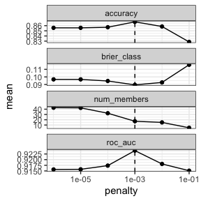

```r
autoplot(tree_frogs_model_st)
```

To show the relationship more directly:

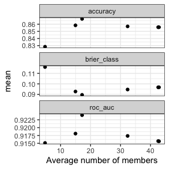

```r
autoplot(tree_frogs_model_st, type = "members")
```

If these results were not good enough, `blend_predictions()` could be called again with different values of `penalty`. As it is, `blend_predictions()` picks the penalty parameter with the numerically optimal results. To see the top results:

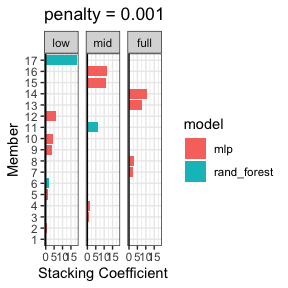

```r
autoplot(tree_frogs_model_st, type = "weights")
```

There are multiple facets since the ensemble members can have different effects on different classes.

To identify which model configurations were assigned what stacking coefficients, we can make use of the `collect_parameters()` function:

```r
collect_parameters(tree_frogs_model_st, "rand_forest_res")
```

```
#> # A tibble: 60 × 6
#>    member                mtry min_n class terms                            coef
#>    <chr>                <int> <int> <chr> <chr>                           <dbl>
#>  1 rand_forest_res_1_01     1    26 low   .pred_mid_rand_forest_res_1_01   18.6
#>  2 rand_forest_res_1_01     1    26 low   .pred_full_rand_forest_res_1_01   0
#>  3 rand_forest_res_1_01     1    26 mid   .pred_mid_rand_forest_res_1_01    0
#>  4 rand_forest_res_1_01     1    26 mid   .pred_full_rand_forest_res_1_01   0
#>  5 rand_forest_res_1_01     1    26 full  .pred_mid_rand_forest_res_1_01    0
#>  6 rand_forest_res_1_01     1    26 full  .pred_full_rand_forest_res_1_01   0
#>  7 rand_forest_res_1_02     2    33 low   .pred_mid_rand_forest_res_1_02    0
#>  8 rand_forest_res_1_02     2    33 low   .pred_full_rand_forest_res_1_02   0
#>  9 rand_forest_res_1_02     2    33 mid   .pred_mid_rand_forest_res_1_02    0
#> 10 rand_forest_res_1_02     2    33 mid   .pred_full_rand_forest_res_1_02   0
#> # ℹ 50 more rows
```

This object is now ready to predict with new data!

```r
tree_frogs_pred <-
  tree_frogs_test %>%
  bind_cols(predict(tree_frogs_model_st, ., type = "prob"))
```

Computing the ROC AUC for the model:

```r
yardstick::roc_auc(
  tree_frogs_pred,
  truth = reflex,
  contains(".pred_")
  )
```

[output not shown]

Looks like our predictions were pretty strong! How do the stacks predictions perform, though, as compared to the members’ predictions? We can use the `members` argument to generate predictions from each of the ensemble members.

```r
tree_frogs_pred <-
  tree_frogs_test %>%
  select(reflex) %>%
  bind_cols(
    predict(
      tree_frogs_model_st,
      tree_frogs_test,
      type = "class",
      members = TRUE
      )
    )

tree_frogs_pred
```

```
#> # A tibble: 303 × 14
#>    reflex .pred_class .pred_class_rand_forest_res_1_01 .pred_class_rand_forest…¹
#>    <fct>  <fct>       <fct>                            <fct>
#>  1 full   full        full                             full
#>  2 mid    mid         low                              mid
#>  3 mid    mid         mid                              mid
#>  4 mid    mid         low                              low
#>  5 full   full        full                             full
#>  6 full   full        full                             full
#>  7 full   full        full                             full
#>  8 full   full        full                             full
#>  9 full   full        full                             full
#> 10 full   full        full                             full
#> # ℹ 293 more rows
#> # ℹ abbreviated name: ¹.pred_class_rand_forest_res_1_07
#> # ℹ 10 more variables: .pred_class_nnet_res_1_06 <fct>,
#> #   .pred_class_nnet_res_1_03 <fct>, .pred_class_nnet_res_1_10 <fct>,
#> #   .pred_class_nnet_res_1_01 <fct>, .pred_class_nnet_res_1_05 <fct>,
#> #   .pred_class_rand_forest_res_1_08 <fct>, .pred_class_nnet_res_1_08 <fct>,
#> #   .pred_class_nnet_res_1_07 <fct>, .pred_class_nnet_res_1_04 <fct>, …
```

```r
map(
  colnames(tree_frogs_pred),
  ~mean(tree_frogs_pred$reflex == pull(tree_frogs_pred, .x))
) %>%
  set_names(colnames(tree_frogs_pred)) %>%
  as_tibble() %>%
  pivot_longer(c(everything(), -reflex))
```

```
#> # A tibble: 13 × 3
#>    reflex name                             value
#>     <dbl> <chr>                            <dbl>
#>  1      1 .pred_class                      0.875
#>  2      1 .pred_class_rand_forest_res_1_01 0.851
#>  3      1 .pred_class_rand_forest_res_1_07 0.868
#>  4      1 .pred_class_nnet_res_1_06        0.848
#>  5      1 .pred_class_nnet_res_1_03        0.848
#>  6      1 .pred_class_nnet_res_1_10        0.845
#>  7      1 .pred_class_nnet_res_1_01        0.842
#>  8      1 .pred_class_nnet_res_1_05        0.789
#>  9      1 .pred_class_rand_forest_res_1_08 0.881
#> 10      1 .pred_class_nnet_res_1_08        0.795
#> 11      1 .pred_class_nnet_res_1_07        0.861
#> 12      1 .pred_class_nnet_res_1_04        0.851
#> 13      1 .pred_class_nnet_res_1_02        0.838
```

Voilà! You’ve now made use of the stacks package to predict tree frog embryo ear function using a stacked ensemble!